# Linear Regression Function

Hermi Balcha

11/22/2020

## Dataset

The dataset used is a dataset from the World Health Organization (https://www.kaggle.com/kumarajarshi/life-expectancy-who). I use this data to predict and explain life expectancy.

## Overall Project Objective

My plan for this linear regression function is to have something that can be called once and perform the required test, choices and graphs to give a good predictive and explanatory model. The function mainly prints the steps taken, the outcome of those steps and the reason for those steps. Even though that was the plan, there were some unavoidable data cleanup situations. When those occur, I left a #not universal comment.

## Issues with the function

The function runs into problems when trying to transform the data. This is because, in an effort to make the function work with most numerical data, I used paste(y~ …) for the lm() and glmnet() calls. Even though they work perfectly there, the transformations could not be completed automatically. Instead, I have included a dependent function for transformations that need to be called manually and printed out statements where the transformation is applied.

## Running a predictive model

```
        [1] "*****************************************************************************************"
        [1] "                             Basic Data Cleanup                                          "
        [1] "*****************************************************************************************"
        [1] "                                                                                         "
        [1] "_________________________________________________________________________________________"
        [1] "                               Head of the dataset                                       "
        [1] "_________________________________________________________________________________________"
        [1] "                                                                                         "
        [1] "                                                                                         "
        [1] "                                                                                         "
              Country Year     Status Adult.Mortality infant.deaths Alcohol
        1 Afghanistan 2015 Developing             263            62    0.01
        2 Afghanistan 2014 Developing             271            64    0.01
        3 Afghanistan 2013 Developing             268            66    0.01
          percentage.expenditure Hepatitis.B Measles  BMI under.five.deaths Polio
        1               71.27962          65    1154 19.1                83     6
        2               73.52358          62     492 18.6                86    58
        3               73.21924          64     430 18.1                89    62
          Total.expenditure Diphtheria HIV.AIDS      GDP Population
        1              8.16         65      0.1 584.2592   33736494
        2              8.18         62      0.1 612.6965     327582
        3              8.13         64      0.1 631.7450   31731688
          thinness..1.19.years thinness.5.9.years Income.composition.of.resources
        1                 17.2               17.3                           0.479
        2                 17.5               17.5                           0.476
        3                 17.7               17.7                           0.470
          Schooling
        1      10.1
        2      10.0
        3       9.9
        [1] "                                                                                         "
        [1] "                                                                                         "
        [1] "                                                                                         "
        [1] "_________________________________________________________________________________________"
        [1] "                                 Summary of the dataset                                  "
        [1] "_________________________________________________________________________________________"
        [1] "                                                                                         "
        [1] "                                                                                         "
        [1] "                                                                                         "
           Country               Year         Status          Adult.Mortality
```

[output cut: 54 more lines]

```
        [1] "                                                                                         "
        [1] "There are missing values in X.                                                           "
        [1] "                                                                                         "
        [1] "Columns missing 50% of their data have been removed.                                     "
        [1] "                                                                                         "
        [1] "Since number of rows is greater than 1000, rows with missing data have been removed.     "
        [1] "                                                                                         "
        [1] "Number of rows remaining:                                                                "
        [1] 1649
        [1] "                                                                                         "
        [1] "Number of columns remaining (excludes y):                                                "
        [1] 20
        [1] "                                                                                         "
        [1] "                                                                                         "
        [1] "Outliers in y:                                                                       "
```

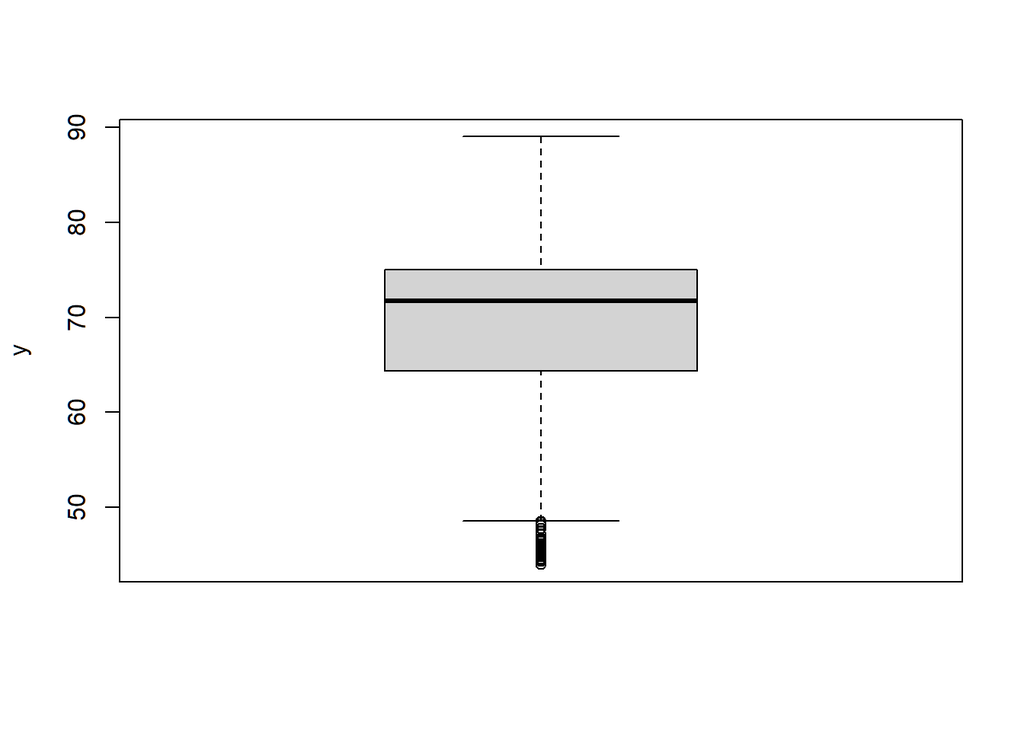

```
         [1] 48.2 48.1 46.4 46.0 46.7 47.8 47.8 46.2 45.3 44.5 44.8 45.5 48.5 47.1 46.0
        [16] 45.1 44.6 44.0 48.1 48.1 47.1 46.2 45.3 47.8 46.0 45.6 45.9 46.4 47.1 48.4
        [31] 48.2 46.6 45.4 44.6 44.3 44.5 44.8 45.3 46.0
        [1] "                                                                                         "
        [1] "Outliers have been removed.                                                              "
        [1] "                                                                                         "
        [1] "*****************************************************************************************"
        [1] "                                    Data Visualization                                   "
        [1] "*****************************************************************************************"
        [1] "                                                                                         "
        [1] "Distribution of y:                                                                       "
```

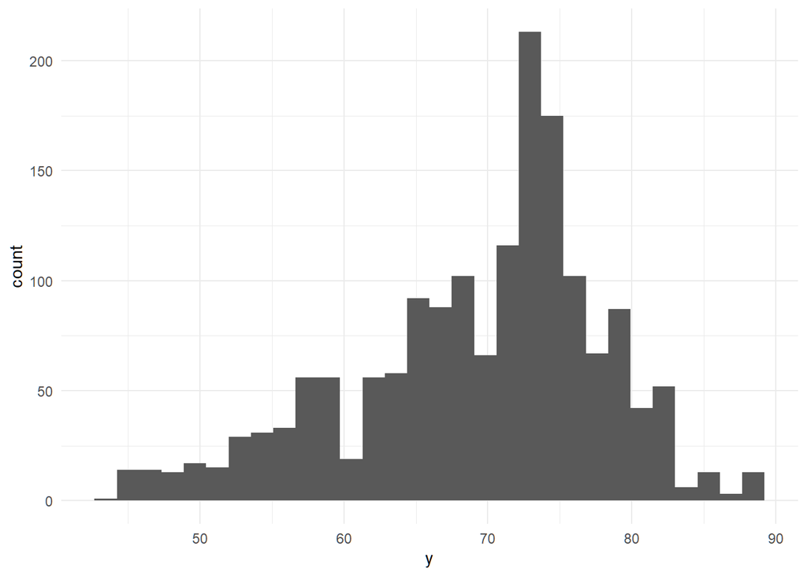

```
        [1] "                                                                                         "
        [1] "Graphical distribution and correlation of columns with y:                                "
        [1] "                                                                                         "
```

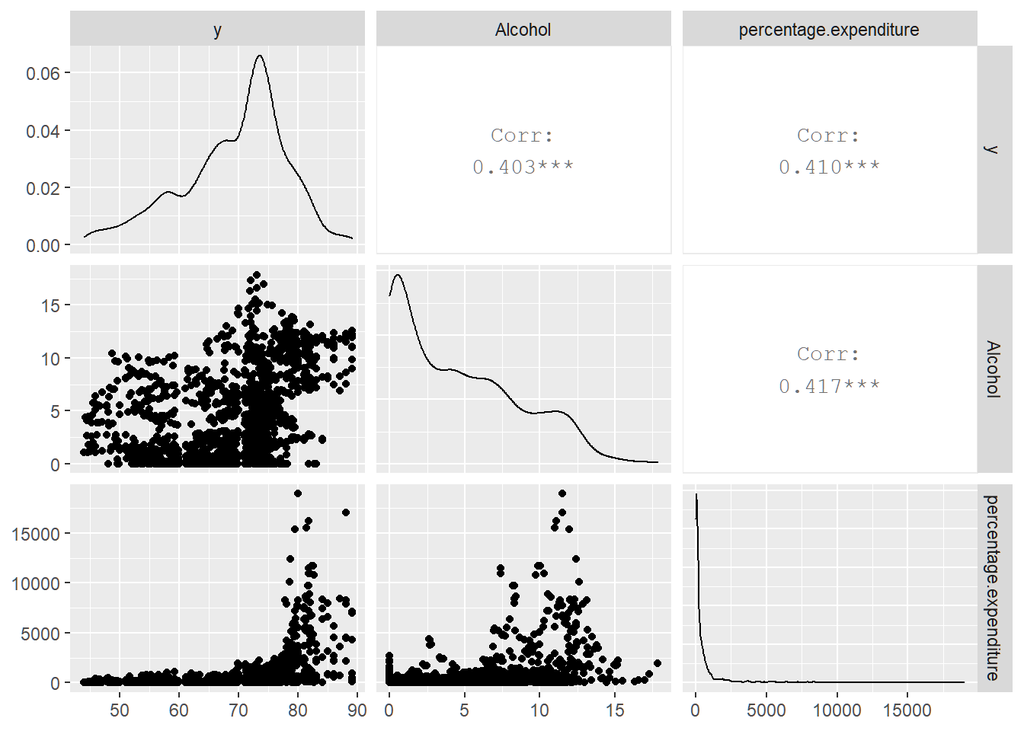

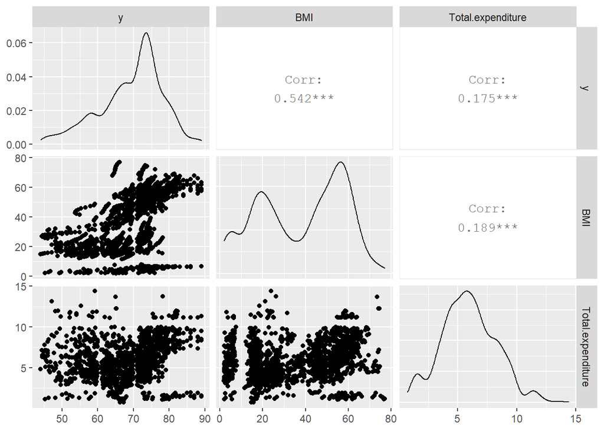

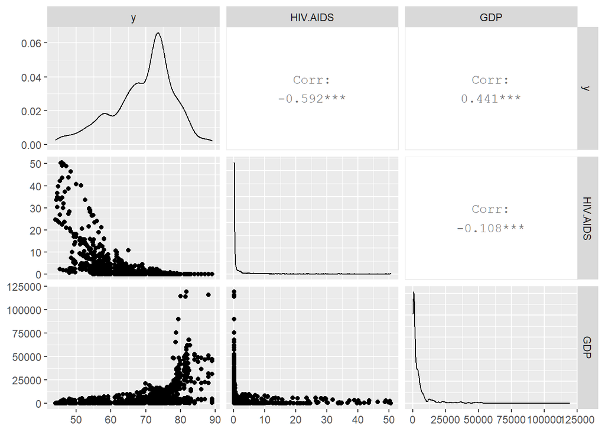

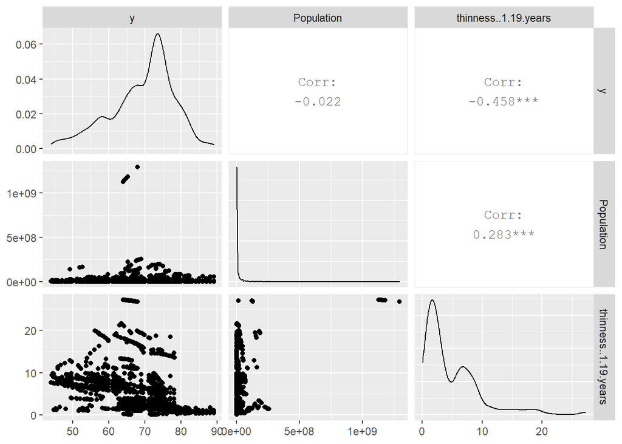

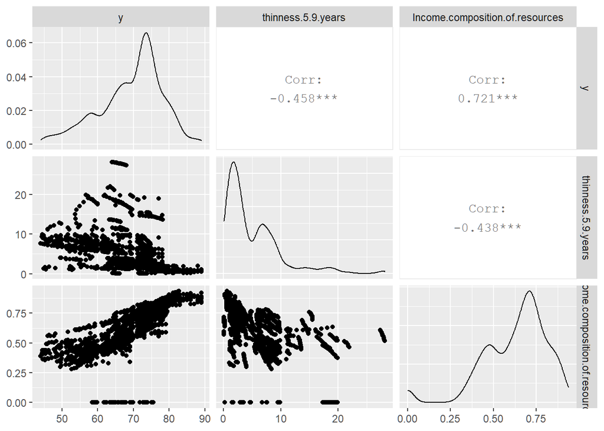

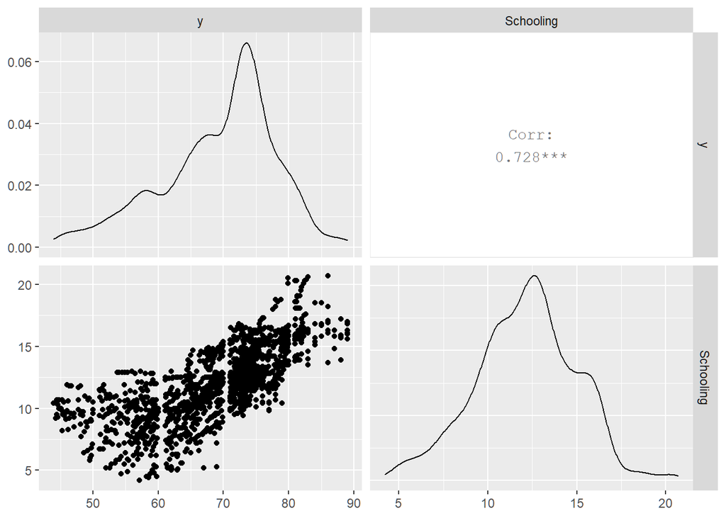

```
        [1] "                                                                                         "
        [1] "                                                                                         "
        [1] "*****************************************************************************************"
        [1] "                           Predictive Regression                                         "
        [1] "*****************************************************************************************"
        [1] "                                                                                         "
        [1] "                                                                                         "
        [1] "33.3% of data held for testing.                                                          "
        [1] "The objective is to minimize MSPE.                                                       "
        [1] "                                                                                         "
        [1] "                                                                                         "
        [1] "Shrinkage Effect of Ridge on the Entire Model:                                           "
        [1] "                                                                                         "
```

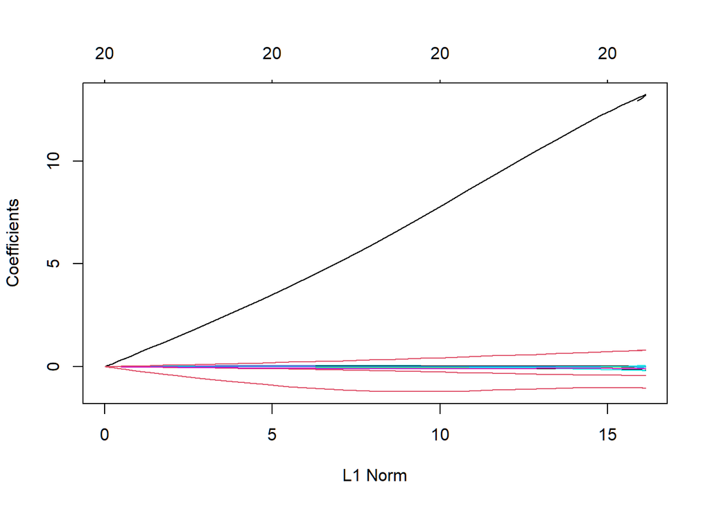

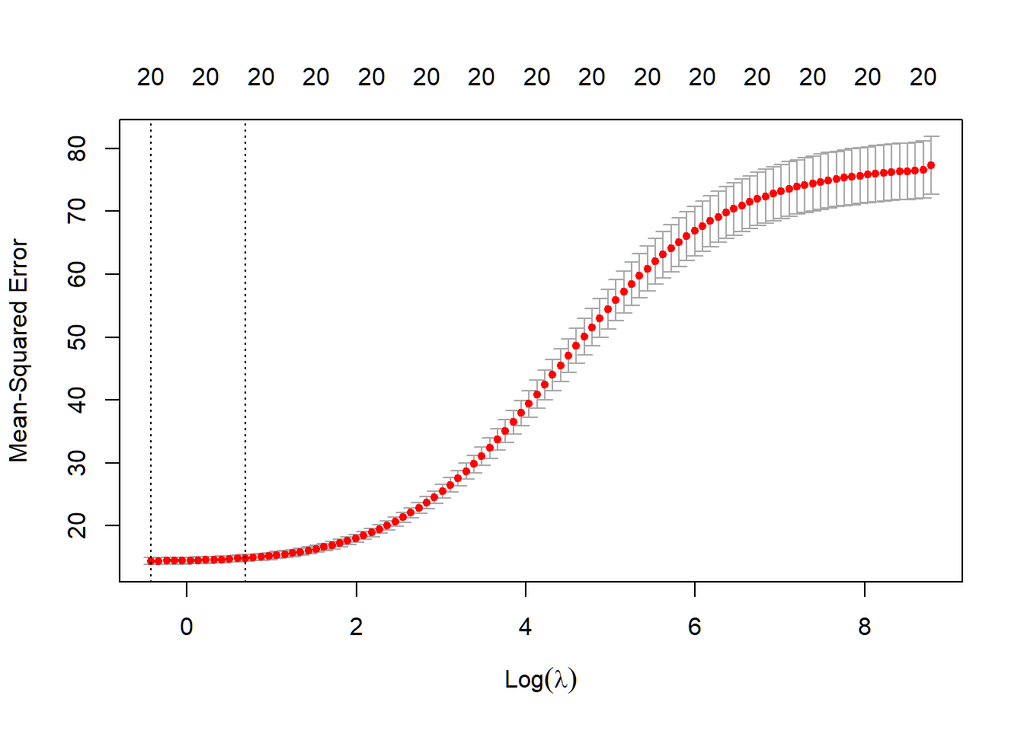

```
        [1] "                                                                                         "
        [1] "Shrinkage Effect of Lasso on the Entire Model:                                           "
        [1] "                                                                                         "
```

[figure not shown]

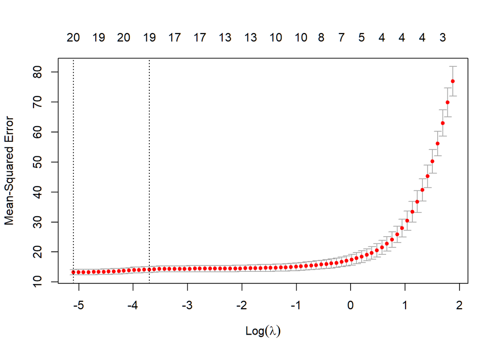

```
        [1] "Comparing Ridge and Lasso regression:                                                    "
        [1] "                                                                                         "
        [1] "Comparing the MSPE of the two models, we get:                                            "
        [1] "                                                                                         "
             Ridge    Lasso
        1 13.47151 13.09365
        [1] "The best predictive model is Lasso.                                                      "
        [1] "                                                                                         "
        [1] "Coefficients of the final model:                                                         "
        [1] "                                                                                         "
        22 x 1 sparse Matrix of class "dgCMatrix"
                                                   s0
        (Intercept)                      3.130962e+02
        (Intercept)                      .
        Year                            -1.293513e-01
        StatusDeveloping                -8.548450e-01
        Adult.Mortality                 -1.649461e-02
        infant.deaths                    6.343611e-02
        Alcohol                         -1.387260e-01
        percentage.expenditure           2.986492e-04
        Hepatitis.B                     -2.653481e-03
        Measles                         -3.169507e-06
        BMI                              3.236439e-02
        under.five.deaths               -4.834045e-02
        Polio                            6.096701e-03
        Total.expenditure                8.834509e-02
        Diphtheria                       1.490389e-02
        HIV.AIDS                        -4.482154e-01
        GDP                              2.461811e-05
        Population                       1.779857e-10
        thinness..1.19.years            -7.733200e-03
        thinness.5.9.years              -4.043624e-02
        Income.composition.of.resources  1.058896e+01
        Schooling                        9.002626e-01
        [1] "                                                                                         "
        [1] "                                                                                         "
        [1] "                                                                                         "
```

## Exploritory model

For the exploratory model, I used Lasso for feature selection since it run faster and was universal to the fucntion than completing AIC, BIC and AdjustedR2. The function for those is still provided as a dependent function and can be switched.

```r
lin_reg(X, y)
```

```
## [1] "*****************************************************************************************"
## [1] "                             Basic Data Cleanup                                          "
## [1] "*****************************************************************************************"
## [1] "                                                                                         "
## [1] "_________________________________________________________________________________________"
## [1] "                               Head of the dataset                                       "
## [1] "_________________________________________________________________________________________"
## [1] "                                                                                         "
## [1] "                                                                                         "
## [1] "                                                                                         "
##       Country Year     Status Adult.Mortality infant.deaths Alcohol
## 1 Afghanistan 2015 Developing             263            62    0.01
## 2 Afghanistan 2014 Developing             271            64    0.01
## 3 Afghanistan 2013 Developing             268            66    0.01
##   percentage.expenditure Hepatitis.B Measles  BMI under.five.deaths Polio
## 1               71.27962          65    1154 19.1                83     6
## 2               73.52358          62     492 18.6                86    58
## 3               73.21924          64     430 18.1                89    62
##   Total.expenditure Diphtheria HIV.AIDS      GDP Population
## 1              8.16         65      0.1 584.2592   33736494
## 2              8.18         62      0.1 612.6965     327582
## 3              8.13         64      0.1 631.7450   31731688
##   thinness..1.19.years thinness.5.9.years Income.composition.of.resources
## 1                 17.2               17.3                           0.479
## 2                 17.5               17.5                           0.476
## 3                 17.7               17.7                           0.470
##   Schooling
## 1      10.1
## 2      10.0
## 3       9.9
## [1] "                                                                                         "
## [1] "                                                                                         "
## [1] "                                                                                         "
## [1] "_________________________________________________________________________________________"
## [1] "                                 Summary of the dataset                                  "
## [1] "_________________________________________________________________________________________"
## [1] "                                                                                         "
## [1] "                                                                                         "
## [1] "                                                                                         "
##    Country               Year         Status          Adult.Mortality
```

[output cut: 54 more lines]

```
## [1] "                                                                                         "
## [1] "There are missing values in X.                                                           "
## [1] "                                                                                         "
## [1] "Columns missing 50% of their data have been removed.                                     "
## [1] "                                                                                         "
## [1] "Since number of rows is greater than 1000, rows with missing data have been removed.     "
## [1] "                                                                                         "
## [1] "Number of rows remaining:                                                                "
## [1] 1649
## [1] "                                                                                         "
## [1] "Number of columns remaining (excludes y):                                                "
## [1] 20
## [1] "                                                                                         "
## [1] "                                                                                         "
## [1] "Outliers in y:                                                                       "
```

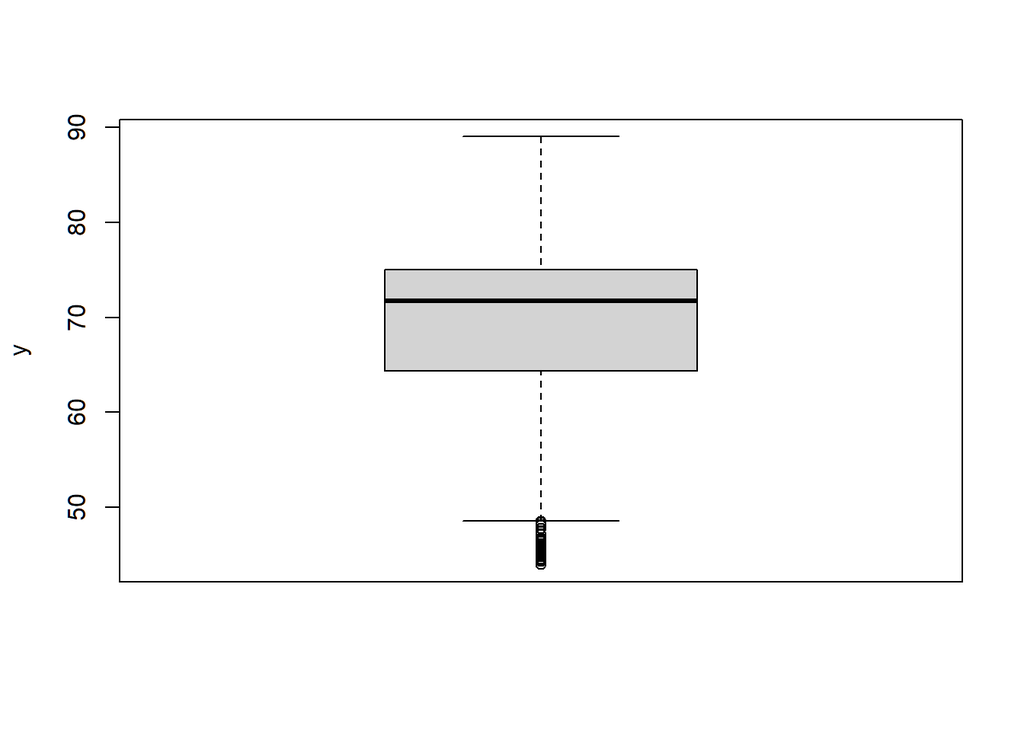

```
##  [1] 48.2 48.1 46.4 46.0 46.7 47.8 47.8 46.2 45.3 44.5 44.8 45.5 48.5 47.1 46.0
## [16] 45.1 44.6 44.0 48.1 48.1 47.1 46.2 45.3 47.8 46.0 45.6 45.9 46.4 47.1 48.4
## [31] 48.2 46.6 45.4 44.6 44.3 44.5 44.8 45.3 46.0
## [1] "                                                                                         "
## [1] "Outliers have been removed.                                                              "
## [1] "                                                                                         "
## [1] "*****************************************************************************************"
## [1] "                                    Data Visualization                                   "
## [1] "*****************************************************************************************"
## [1] "                                                                                         "
## [1] "Distribution of y:                                                                       "
```

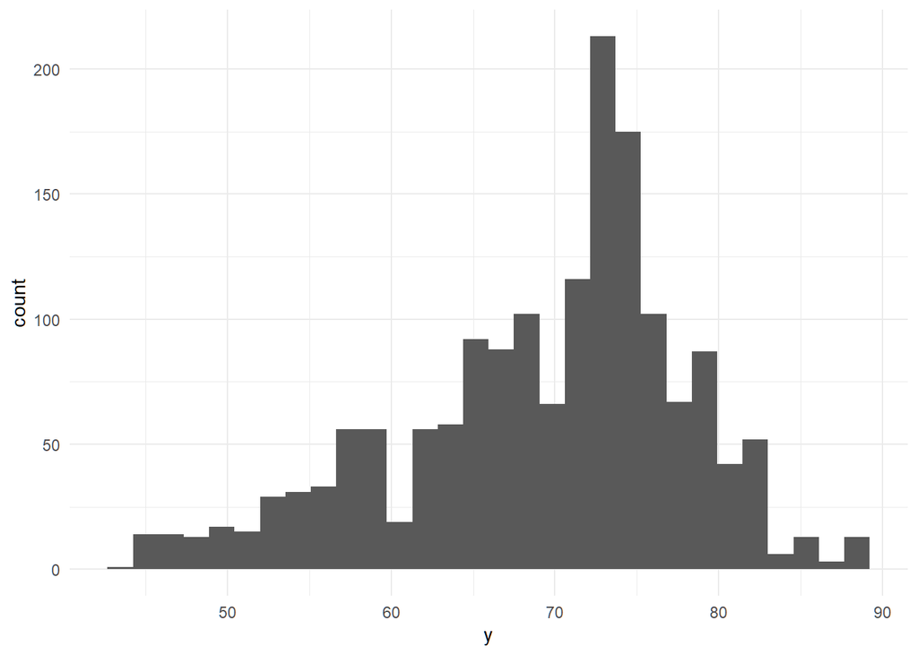

```
## [1] "                                                                                         "
## [1] "Graphical distribution and correlation of columns with y:                                "
## [1] "                                                                                         "
```

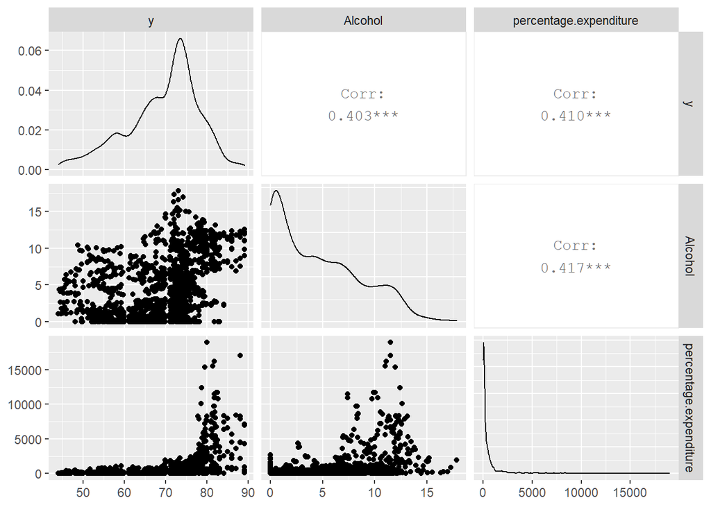

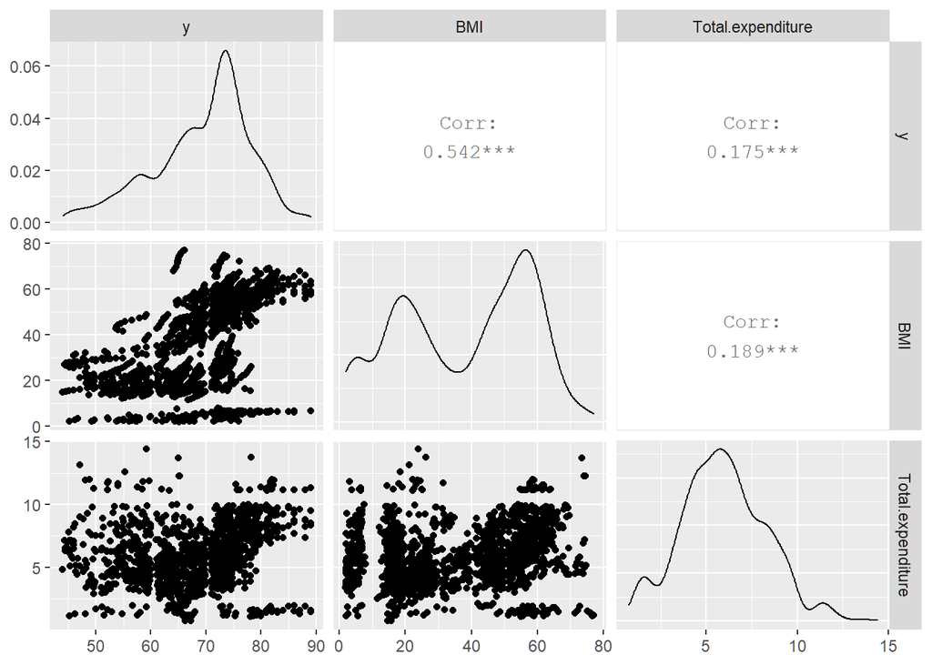

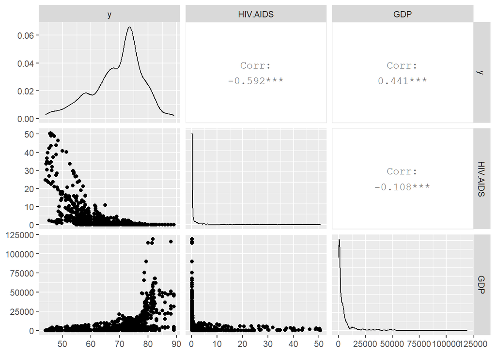

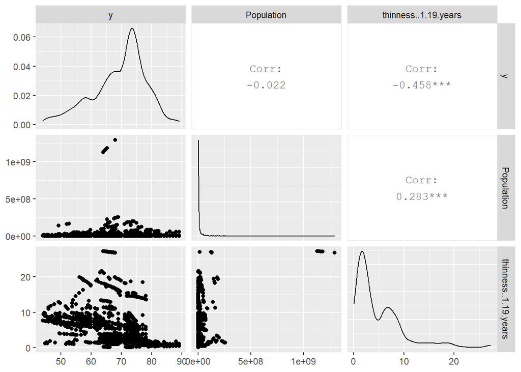

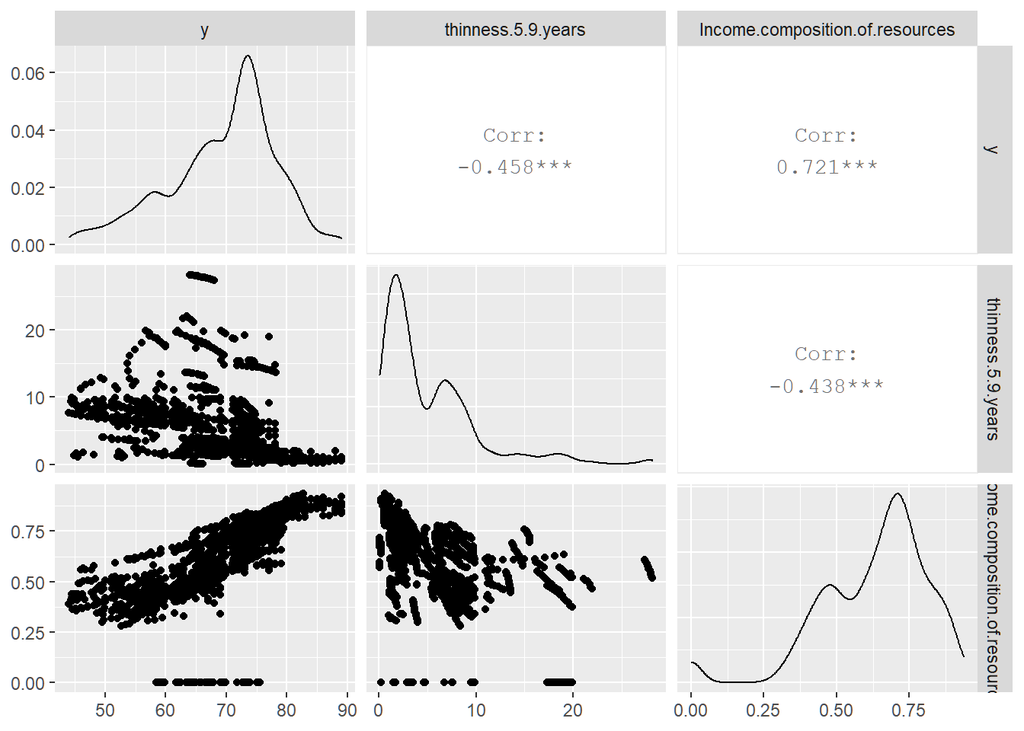

```
## [1] "                                                                                         "
## [1] "                                                                                         "
## [1] "*****************************************************************************************"
## [1] "                           Exploratory Regression                                        "
## [1] "*****************************************************************************************"
## [1] "                                                                                         "
## [1] "                                                                                         "
## [1] "_________________________________________________________________________________________"
## [1] "                   Variable selection using Lasso                                        "
## [1] "_________________________________________________________________________________________"
## [1] "                                                                                         "
## [1] "                                                                                         "
## [1] "Variable weights from lasso regression:                                                  "
## [1] "                                                                                         "
##                     (Intercept)                     (Intercept)
##                    5.459919e+01                    0.000000e+00
##                            Year                StatusDeveloping
##                    0.000000e+00                    0.000000e+00
##                 Adult.Mortality                   infant.deaths
##                   -1.745980e-02                    0.000000e+00
##                         Alcohol          percentage.expenditure
##                    0.000000e+00                    8.782884e-05
##                     Hepatitis.B                         Measles
##                    0.000000e+00                    0.000000e+00
##                             BMI               under.five.deaths
##                    2.382979e-02                    0.000000e+00
##                           Polio               Total.expenditure
##                    0.000000e+00                    0.000000e+00
##                      Diphtheria                        HIV.AIDS
##                    2.082081e-03                   -3.719259e-01
##                             GDP                      Population
##                    1.506281e-05                    0.000000e+00
##            thinness..1.19.years              thinness.5.9.years
##                    0.000000e+00                   -1.538132e-03
## Income.composition.of.resources                       Schooling
##                    9.799943e+00                    9.049015e-01
## [1] "                                                                                         "
## [1] "                                                                                         "
## [1] "                                                                                         "
## [1] "_________________________________________________________________________________________"
```

[output cut: 16 more lines]

```
## Adult.Mortality                 -1.831e-02  9.584e-04 -19.103  < 2e-16 ***
## percentage.expenditure           3.695e-04  1.851e-04   1.996   0.0461 *
## BMI                              3.599e-02  6.139e-03   5.863 5.49e-09 ***
## Diphtheria                       2.325e-02  4.560e-03   5.098 3.83e-07 ***
## HIV.AIDS                        -4.398e-01  1.819e-02 -24.174  < 2e-16 ***
## GDP                              8.517e-06  2.918e-05   0.292   0.7704
## thinness.5.9.years              -5.543e-02  2.442e-02  -2.270   0.0233 *
## Income.composition.of.resources  9.760e+00  8.424e-01  11.586  < 2e-16 ***
## Schooling                        8.793e-01  5.745e-02  15.305  < 2e-16 ***
## ---
## Signif. codes:  0 '***' 0.001 '**' 0.01 '*' 0.05 '.' 0.1 ' ' 1
##
## Residual standard error: 3.706 on 1639 degrees of freedom
## Multiple R-squared:  0.8235, Adjusted R-squared:  0.8225
## F-statistic: 849.6 on 9 and 1639 DF,  p-value: < 2.2e-16
```

[figure not shown]

```
## [1] "                                                                                         "
## [1] "                                                                                         "
## [1] "Performing diagnostic tests on this model:                                               "
## [1] "                                                                                         "
## [1] "                                                                                         "
## [1] "                                                                                         "
## [1] "Performed wilks-shapiro test of normality.                                               "
## [1] "Residuals are not normally distributed! We don't want that.                            "
## [1] "                                                                                         "
## [1] "Performed Breusch-pagan test of homoskedasticity.                                        "
## [1] "The variablity of variance is heteroskedastic! We don't want that.                     "
## [1] "                                                                                         "
## [1] "Testing Linearity based on correlation of fitted values and residuals.                   "
## [1] "The correlation between the fitted values and residuals is low! Correllation is:       "
## [1] 9.012099e-17
```